# A3: Incarceration

Matt Ramirez

2/21/2021

### Introduction and Summary Information

Incarceration rates among the black community has been a grave topic of discussion in the United States for some time now. It is a true manifestation of racism and can be seen through the variables I have chosen to analyze. I wanted to focus in on the rates among the black community specifically because I am interested to see the true proportion of incarceration among blacks compared to other races.

The five variables I will be using are:

- total_jail_pop
- black_jail_pop_rate
- black_jail_pop
- year
- black_prison_pop

I decided to use year, total jail population, black jail population rate, black jail population, and black prison population because I felt that these variables will best display the disparity of incarceration rates between the black community and other racial groups.

Five questions I am going to use to calculate relevant values are:

What county had the highest number of blacks in jail in the most recent year?

Los Angeles County

What county had the highest number of whites in jail in the most recent year?

Maricopa County

What year had the most number of blacks in Jail in a single county?

1993

What state had the highest number of whites in jail in the most recent year?

Arizona

What state has the highest number of blacks in jail in the most recent year?

California

### Trends over time chart

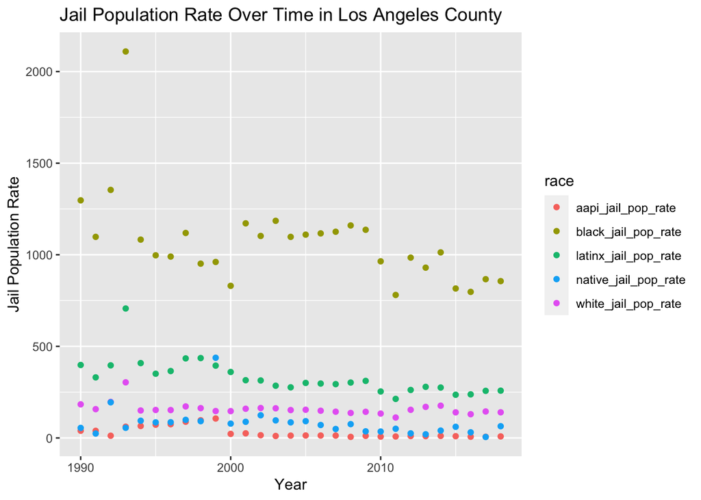

Above is a graph of the Jail Population in Los Angeles County from 1990 to 2018. I decided to show this chart because it clearly depicts the rate at which blacks are being incarcerated in comparison to other racial groups. From the chart, we can see that the jail population rate in Los Angeles County of blacks are consistently higher that other racial groups. While the population rate of blacks does seem to have a slight downward trend, it is still significantly higher than those of the other racial groups.

### Variable Comparison Chart

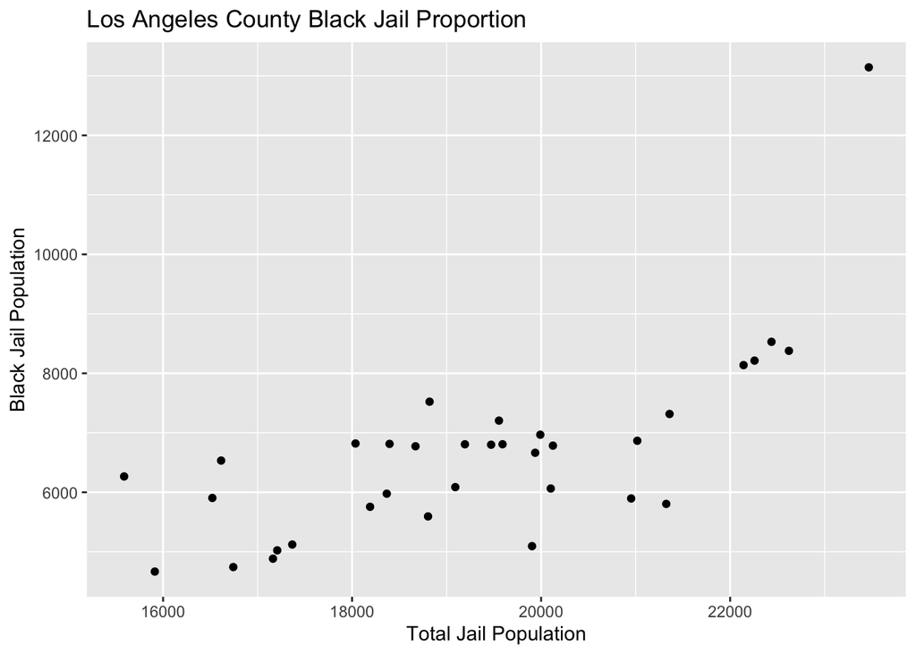

Above is a chart chowing the black jail population in comparison to the total jail population in Los Angeles County. I decided to compare these two variables because I wanted to show the trend of black jail population as total jail population increases. From the chart, we can see a somewhat positive relationship between the two variables.

### Map

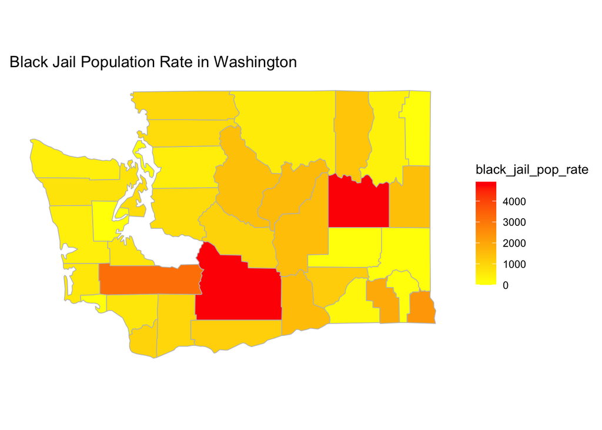

Above is a map that shows the black jail population rate in Washington state. I decided to include this because I wanted to see the rate distribution throughout Washington state. From the map, the majority of counties seem to be either yellow or light orange, indicating that the majority of black jail population rates are in the range of 0-2500. However, there are two counties that have rates greater than 4000.